# CMSC320 Final Project - Analyzing Seasonal Anime

by Jacob Clements

### Introduction

In this tutorial, I will be going through the data science pipeline of data collection, data tidying, exploratory data analysis, hypothesis testing, and machine learning. The data set I've chosen to work with is about anime. If you don't know what anime is, anime is a term used for Japanese animation. Anime comes in all shapes and forms, with many different genres and animation and art styles. Anime is released on a seasonal basis, with a new wave of shows coming out with an episode a week starting every January, April, July, and October. Shows starting in January are refered to as "winter" anime, shows starting in April are "spring" anime, shows starting in July are "summer" anime, and shows starting in October are "fall" anime. Because the anime community mostly discusses the current season of anime, as an anime watcher, I am particularly interested in seeing what traits the most popular shows per season have. Other things to explore include looking at what factors affect how good the community thinks the show is, or what genres the community prefers. But without further ado, let's get started!

### Modules Used

The programming language we'll be using is Python, and before we get coding, we have to import some useful modules. The main modules we'll be using are requests and BeautifulSoup for webscraping, pandas for representing the data in DataFrames, matplotlib for plotting our data, and sklearn for machine learning.

```python
import requests
from bs4 import BeautifulSoup
import time
from datetime import datetime
import pandas as pd
import numpy as np
import matplotlib.pyplot as plt
import matplotlib.image as img
%matplotlib inline
from sklearn import linear_model
from sklearn.model_selection import cross_val_score
from sklearn.neighbors import KNeighborsClassifier
import statsmodels.api as sm
import warnings
warnings.filterwarnings('ignore')
```

## Data Collection

The first step of the data science pipeline is data collection. I looked around for some public data sets on anime, but the ones I saw were lacking in some interesting features such as audience score and popularity rankings. A possible solution to this is to use a public data set that has some of the data we want, and to simply get the features we want for each show and add it to the data set. However, joining 2 data sets about anime would be difficult because the names of the shows might not be the same when they actually refer to the same shows. For example, the show "So Ra No Wo To" can also be called "Sora no Woto," "The Sound of the Sky," or even "ソ・ラ・ノ・ヲ・ト." Because of this complication, adding data to an existing data set by matching according to a show's name is acutally very difficult, so the best alternative is to construct the entire data set ourselves. To do this, we'll be using web scraping, which means we'll be directly downloading webpages and parsing them for the data we want.

### Web Scraping: Where is it Coming From and What Data are We Going to Collect?

Web scraping can be very tedious and time consuming, so it's best to break things down. For starters, the website that we'll be getting our data from is called MyAnimeList.net, which is one of the most popular websites for tracking anime among the English speaking audience. MyAnimeList users actively add shows to their profiles and often score them, which means that each show has information on it's audience score and it's popularity. For the data we are collecting, it is important that we get enough features for each show, so that we don't have to go back and rerun the web scraper, which can be time consuming. The data I've chosen to collect for a show is it's name, score ranking, popularity ranking, total members (how many users added it their profiles as completed, watching, plan to watch, on hold, or dropped), the year and season of it's release, its number of episodes, the studio that made it, the source material, its genres, and its score. Each show also has a list of its main characters and their voice actors. These voice actors have their own pages on the website, and users can 'favorite' these actors. Another thing we'll be getting for each show that might be interesting is the average number of favorites for the show's main cast.

### Web Scraping: Approach

Now, on to the actual web scraping. After looking around, I've found out that there are 3 main webpages that we'll have to parse:

1. Because the seasonal cycle is so important to the anime community, each season of each year has its own webpage on the website. We'll be using these pages to acquire links to the pages of the individual shows for each season. It's worth noting that many shows span multiple seasons--in these cases, the shows are only listed for the season the show started airing on.
2. For each show's individual page, we'll have to parse for that show's information. Also on this page are links to the voice actors' pages for the main characters of the show.
3. For each voice actor's page, we'll have to parse for the number of users that have favorited them.

[figure not shown]

```python
seasonal_chart = img.imread('Seasonal List Example.PNG')

#we need a huge figure or it will automatically compress the image when displaying it
plt.figure(figsize=(60,60))
plt.imshow(seasonal_chart)
plt.title('Seasonal Chart')
plt.show()
```

The image above is an example of the webpage for a season. Inside these pages are cards for each show. We'll use these cards to get the links for each individual show. We can predict the url's of each season because they follow a predictable pattern using the year and name for each season.

[figure not shown]

```python
show_webpage = img.imread('Show Example.PNG')

# we need a huge figure or it will automatically compress the image when displaying it
plt.figure(figsize=(60,60))
plt.imshow(show_webpage)
plt.title("A Show's Webpage")
plt.show()
```

The above image shows the layout of a show's individual page, and how we'll parse it to get the data we need. The information in the red box towards the top can be aquired by parsing for 'strong' html elements. In the vertical tab on the left boxed in blue, we need the information inside the red box, so we'll have to find where the 'Information' category starts and parse from there. Lastly, we'll have to look through the list of character-actor pairs and get a link for each actor's personal page if the character they voice is a main character in the show.

[figure not shown]

```python
voice_actor_webpage = img.imread('Voice Actor Example.PNG')

# we need a huge figure or it will automatically compress the image when displaying it
plt.figure(figsize=(60,60))
plt.imshow(voice_actor_webpage)
plt.title("A Voice Actor's Webpage")
plt.show()
```

The image above is what an individual actor's page looks like. For these pages, we'll only be looking for the information corresponding to "Member Favorites:," which is held within the tab to the left.

### Web Scraping: One Last Note

Finally, we'll put the approach described above into code and get the information we need. Because the web scraping code takes a long time to execute, the information we'll be getting will be limited to the years 2010 to 2019 inclusive. This will give us enough data to analyze for shows that have finished airing. Additionally, I've only gathered data for shows that have greater than 30,000 members. I did this mainly because of time constraints, but this also guarantees a minimum amount of quality in the shows we have gathered. For instance, because such a small amount of people are watching these shows, their webpages might have missing data, or they might have no official translations and are thus not available to watch legally for most English speakers. Because we've limited our data in this way, the results of any analysis we do is only valid for shows that have a minimum amount of interest in them, which for this case is 30,000 members or more.  
Now, let's get scraping!

```python
# this dictionary holds 'actor_name' : number of favorites by users
actors_dict = {}
# the columns reflect the data we are collecting for each show
columns=['name','score_rank','popularity_rank','members','year','season','episodes','studio','source','genres','score','ave_main_cast_favorites']
# initialize a pandas DataFrame with the columns defined above
df = pd.DataFrame(columns=columns)
```

```python
# defining some useful functions

def ParseInfoDiv(text):
    '''
    This function takes in a string that looks like '\n\n   info\n' and extracts 'info' from the string.
    Strings that look like this are common in the elements of a show's information tab.
    '''

    info = ''
    newline_count = 0

    # loop over each character, parse using the newlines in text
    for i,char in enumerate(text):
        if char == '\n':
            newline_count += 1
        if newline_count == 2:
            info += char
        elif newline_count == 3:
            break
    # make sure to get rid of any whitespace before returning
    return info[1:len(info)].strip()

def GetActorFavorites(link):
    '''
    This function takes a link to a voice actor's webpage and gets their number of favorites,
    where favorites are the number of users that 'favorited' the actor
    '''

    # wait a little bit so we don't bombard the website with requests that are too closely spaced
    wait = np.random.rand() * 2
    time.sleep(wait)

    # get webpage
    r = requests.get(link)

    # parse the html with BeautifulSoup
    soup = BeautifulSoup(r.text, 'html.parser')

    # get all the divs with the css class we're looking for
    divs = soup.find('td').select('div',class_='spaceit_pad')

    # loop over all the chosen divs and find the one with 'Member Favorites:' in it
    for i,div in enumerate(divs):
        if 'Member Favorites:' in div.text:
#             print('found fav')
            # parse through the div and extract the number of favorites from the text
            num_favorites = ''
            start = False
            for char in div.text:
                if start:
                    num_favorites += char
                elif char == ':': # start collecting the favorites after the ':' is seen
                    start = True
            num_favorites = num_favorites.strip().replace(',','')
            return int(num_favorites)
#     print('did not find fav')
    return 0

def MainCastPopularity(soup, actors_dict):
    '''
    This functon takes in a show's webpage parsed with beautifulsoup and a dictionary of the form
    'actor_name':number of favorites. This function returns the average number of favorites in
    the show's main cast.
    '''

    favorites = []

    # get the region of the webpage that holds the character and voice actor information
    characters_divs = soup.select('div',class_='detail-characters-list clearfix')
    characters_table = characters_divs[0].select('table')

    # the info we want usually starts at index 4 but rarely it starts at 3
    # I have yet to find a cleaner solution
    start = 4
    for i in [4,3]:
        try:
            characters_table[i].select('td',class_='borderClass')[1].find('small').text
            start = i
            break
        except:
            continue


    # keep looping until we get all the main actors
    while True:
        # get the role type of the character (Main or Supporting)
        role_type = characters_table[start].select('td',class_='borderClass')[1].find('small').text

        if not role_type == 'Main':
            break

        # extract the actor's name and a link to their MyAnimeList webpage
        if len(characters_table[start+1].select('td',class_='borderClass')) == 0:  # it can be the case that no actor is listed!
            favorites.append(0)  # put zero in the case the actor has no MAL page or is unknown
            start += 2
            continue
        actor = characters_table[start+1].select('td',class_='borderClass')[0].find('a')
        actor_name = actor.text
        actor_link = actor['href']

        # if the actor is in the dictionary, look it up
        # else, scrape their webpage and add it to the dicitonary
        if actor_name in actors_dict:
            num_favorites = actors_dict[actor_name]
        else:
            num_favorites = GetActorFavorites(actor_link)
            actors_dict[actor_name] = num_favorites

        favorites.append(num_favorites)
        start += 2  # move on to the next character/actor pair

#         print(actor_link)
    if len(favorites) == 0:  # make sure we don't accidently divide by zero
        return 0
    else:
        return sum(favorites)/len(favorites)
```

```python
# loop over each year and each season in each year for the years 2010-2019
for year in range(2010,2020):
    for season in ['winter','spring','summer','fall']:
#         print('Scraping {} season of year {}'.format(season,year))

        # downlaod the webpage
        season_request = requests.get('https://myanimelist.net/anime/season/{}/{}'.format(year,season))

        # parse the webpage with BeautifulSoup
        season_soup = BeautifulSoup(season_request.text, 'html.parser')

        # now loop to get the link for each show and get the show's info
        seasonal_shows = season_soup.select('div',class_='seasonal-anime js-seasonal-anime')
        for show in seasonal_shows[0].select('h2'):
            # I don't want my scraping to look like a DOS attack, so space out the requests
            wait = np.random.rand() * 10
            time.sleep(wait)

            # get the link to the show's webpage
            show_link = show.find('a')['href']

            # get the webpage for the show
            show_request = requests.get(show_link)

            # parse the html with BeautifulSoup
            soup = BeautifulSoup(show_request.text, 'html.parser')

            # get the title, score ranking, popularity ranking, and total members
            major_info = soup.find_all('strong')

            title = major_info[0].text
            score_ranking = major_info[1].text
            popularity_ranking = major_info[2].text
            members = major_info[3].text

            # convert members to a number so we can decide when to stop scraping for each season
            members = int((members.strip()).replace(',',''))

            if members < 30000:
                break

            # scrape the 'Information' tab on the webpage
            # selecting the first td element gives us all of the information on the left side of the page
            # of all the div elements in the first td element, we need to find the index where the Information section starts
            side_tab = soup.select('td')[0].select('div')
            info_start = 0
            for index, row in enumerate(side_tab):
                if row.text == '\nType:\nTV':  # the Information section starts here
                    info_start = index
                    break

            # get information from the Information tab
            # first get the number of episodes
            episodes_text = side_tab[info_start + 1].text
            if 'Unknown' in episodes_text:
                episodes = pd.NA
            else:
                # search the text for an integer to get the number of episodes
                episodes = [int(s) for s in episodes_text.split() if s.isdigit()][0]

            # get the studio that made the show
            if 'None found' in side_tab[info_start + 8]:
                studio = pd.NA
            else:
                studio = side_tab[info_start + 8].find('a')['title']

            # get the source material (light novel, manga, original, etc)
            source = ParseInfoDiv(side_tab[info_start + 9].text)

            # for each genre listed, add it to a list called genres
            genres = []
            for a_tag in side_tab[info_start + 10].find_all('a'):
                genres.append(a_tag['title'])

            # get the audience score of the show
            score = side_tab[info_start + 13].select('span')[1].text

            # of the main cast of voice actors, get their average amount of favorites
            ave_cast_favorites = MainCastPopularity(soup,actors_dict)

#             print('The title is: {}'.format(title))
#             print('The score ranking is: {}'.format(score_ranking))
#             print('The popularity ranking is: {}'.format(popularity_ranking))
#             print('The total members is: {}'.format(members))
#             print('The number of episodes is: {}'.format(episodes))
#             print('The studio is: {}'.format(studio))
#             print('The source is: {}'.format(source))
#             print('The main genre is: {}'.format(main_genre))
#             print('The score is: {}'.format(score))
#             print('The average cast favorites is: {}'.format(ave_cast_favorites))

            # construct a new row from the collected data
            new_row = [title,score_ranking,popularity_ranking,members,year,season,episodes,studio,source,genres,score,ave_cast_favorites]

            # add the row to the main dataframe
            if len(df) == 0:
                df = pd.DataFrame([new_row],columns=columns)
            else:
                df.loc[len(df)] = new_row


print('Done!')
df.head()
```

```
Done!
```

|  | name | score_rank | popularity_rank | members | year | season | episodes | studio | source | genres | score | ave_main_cast_favorites |
| --- | --- | --- | --- | --- | --- | --- | --- | --- | --- | --- | --- | --- |
| 0 | Durarara!! | #364 | #64 | 1192637 | 2010 | winter | 24 | Brain's Base | Light novel | [Action, Mystery, Supernatural] | 8.15 | 57069.666667 |
| 1 | Baka to Test to Shoukanjuu | #1373 | #246 | 557199 | 2010 | winter | 13 | SILVER LINK. | Light novel | [Comedy, Romance, School, Super Power] | 7.57 | 2748.714286 |
| 2 | Katanagatari | #185 | #319 | 475938 | 2010 | winter | 12 | White Fox | Light novel | [Action, Adventure, Historical, Martial Arts, ... | 8.35 | 3608.000000 |
| 3 | Seikon no Qwaser | #6525 | #577 | 279390 | 2010 | winter | 24 | Hoods Entertainment | Manga | [Action, Super Power, Supernatural, Ecchi, Sei... | 6.41 | 7101.000000 |
| 4 | Omamori Himari | #4164 | #792 | 211766 | 2010 | winter | 12 | Zexcs | Manga | [Action, Harem, Comedy, Demons, Supernatural, ... | 6.89 | 1502.666667 |

We got our data! This concludes the section of data collection and web scraping, but if you're interested, the following resources are helpful for web scraing:

1. BeautifulSoup's official documentation: https://beautiful-soup-4.readthedocs.io/en/latest/
2. Automate the Boring Stuff's chapter on web scraping: https://automatetheboringstuff.com/chapter11/

Just so we don't have to run the web scaper every time, let's save it to a csv (comma separated values) file using pandas.

```python
df.to_csv('raw_data_backup.csv',index=False)
```

To load the data from the csv, all we need to do is call pandas' read_csv. For the reader's convenience, I've uploaded the csv that I got from the web scaper to this project's repository available here.

```python
df = pd.read_csv('raw_data_backup.csv')
```

## Data Tidying

So we got all our data, but it's not quite ready to analyze just yet. First, let's see if there are any missing values.

```python
#show missing values
df.isnull().sum()
```

```
name                       0
score_rank                 0
popularity_rank            0
members                    0
year                       0
season                     0
episodes                   2
studio                     0
source                     0
genres                     0
score                      0
ave_main_cast_favorites    0
dtype: int64
```

So from the results above, there are 2 rows that have missing values for episodes, and 0 for the rest. From the web scraping part, we know that the episodes column would only have a missing value if the number of episodes is missing. On MyAnimeList, the number of episodes is usually missing because the show is ongoing, so the number of episodes is undetermined. Just to check, let's print out the rows corresponding to the missing values.

```python
# display missing values
df[df.isnull().any(axis=1)]
```

|  | name | score_rank | popularity_rank | members | year | season | episodes | studio | source | genres | score | ave_main_cast_favorites |
| --- | --- | --- | --- | --- | --- | --- | --- | --- | --- | --- | --- | --- |
| 822 | Boruto: Naruto Next Generations | #9069 | #207 | 624102 | 2017 | spring | NaN | Studio Pierrot | Manga | ['Action', 'Adventure', 'Super Power', 'Martia... | 5.83 | 187.50 |
| 1175 | Pokemon (2019) | #2824 | #2428 | 49964 | 2019 | fall | NaN | OLM | Game | ['Action', 'Adventure', 'Comedy', 'Kids', 'Fan... | 7.20 | 2975.75 |

A quick lookup of these shows reveals that they are indeed ongoing shows. Because the mix of ongoing vs completed shows in our data set is so unbalanced, we're going to drop these rows from the data set. The consequences of doing this are that the results of our analysis only apply for completed shows, and might not be directly applicable to ongoing shows.

```python
# drop missing values
df = df.dropna()
```

Now that we've taken care of any missing data, let's take a look at the data set using .info()

```python
df.info()
```

```
<class 'pandas.core.frame.DataFrame'>
Int64Index: 1179 entries, 0 to 1180
Data columns (total 12 columns):
 #   Column                   Non-Null Count  Dtype
---  ------                   --------------  -----
 0   name                     1179 non-null   object
 1   score_rank               1179 non-null   object
 2   popularity_rank          1179 non-null   object
 3   members                  1179 non-null   int64
 4   year                     1179 non-null   int64
 5   season                   1179 non-null   object
 6   episodes                 1179 non-null   float64
 7   studio                   1179 non-null   object
 8   source                   1179 non-null   object
 9   genres                   1179 non-null   object
 10  score                    1179 non-null   float64
 11  ave_main_cast_favorites  1179 non-null   float64
dtypes: float64(3), int64(2), object(7)
memory usage: 119.7+ KB
```

From the output of .info(), we can tell that the columns for score rank and popularity rank are objects (strings to be exact), not integers. We're going to convert these columns into numbers because numbers are much more easy to analyze than strings.

```python
# convert score_rank and popularity_rank columns to numbers
df['score_rank'] = df.apply(lambda x: int(x['score_rank'][1:len(x['score_rank'])]), axis=1)
df['popularity_rank'] = df.apply(lambda x: int(x['popularity_rank'][1:len(x['popularity_rank'])]), axis=1)
df.head()
```

|  | name | score_rank | popularity_rank | members | year | season | episodes | studio | source | genres | score | ave_main_cast_favorites |
| --- | --- | --- | --- | --- | --- | --- | --- | --- | --- | --- | --- | --- |
| 0 | Durarara!! | 364 | 64 | 1192637 | 2010 | winter | 24.0 | Brain's Base | Light novel | ['Action', 'Mystery', 'Supernatural'] | 8.15 | 57069.666667 |
| 1 | Baka to Test to Shoukanjuu | 1373 | 246 | 557199 | 2010 | winter | 13.0 | SILVER LINK. | Light novel | ['Comedy', 'Romance', 'School', 'Super Power'] | 7.57 | 2748.714286 |
| 2 | Katanagatari | 185 | 319 | 475938 | 2010 | winter | 12.0 | White Fox | Light novel | ['Action', 'Adventure', 'Historical', 'Martial... | 8.35 | 3608.000000 |
| 3 | Seikon no Qwaser | 6525 | 577 | 279390 | 2010 | winter | 24.0 | Hoods Entertainment | Manga | ['Action', 'Super Power', 'Supernatural', 'Ecc... | 6.41 | 7101.000000 |
| 4 | Omamori Himari | 4164 | 792 | 211766 | 2010 | winter | 12.0 | Zexcs | Manga | ['Action', 'Harem', 'Comedy', 'Demons', 'Super... | 6.89 | 1502.666667 |

One last thing we need to tidy is each show's year and season. We're going to add a column of datetime objects that correspond to the year-season pair for each show. Doing this makes it easier to compare which shows aired before others. For example, if we have datetime objects, we don't have to specify every time that the winter season of 2010 came before the fall season of 2010.

```python
# make datetime column

def GetDatetime(row):
    '''
    This function takes in a row and creates a datetime object from the row's year and season values
    '''
    season = row['season']
    month = 0
    if season == 'winter':
        month = 1
    elif season == 'spring':
        month = 4
    elif season == 'summer':
        month = 7
    elif season == 'fall':
        month = 10

    return datetime(row['year'], month, 1)

df['datetime'] = df.apply(GetDatetime, axis=1)
df.head()
```

|  | name | score_rank | popularity_rank | members | year | season | episodes | studio | source | genres | score | ave_main_cast_favorites | datetime |
| --- | --- | --- | --- | --- | --- | --- | --- | --- | --- | --- | --- | --- | --- |
| 0 | Durarara!! | 364 | 64 | 1192637 | 2010 | winter | 24.0 | Brain's Base | Light novel | ['Action', 'Mystery', 'Supernatural'] | 8.15 | 57069.666667 | 2010-01-01 |
| 1 | Baka to Test to Shoukanjuu | 1373 | 246 | 557199 | 2010 | winter | 13.0 | SILVER LINK. | Light novel | ['Comedy', 'Romance', 'School', 'Super Power'] | 7.57 | 2748.714286 | 2010-01-01 |
| 2 | Katanagatari | 185 | 319 | 475938 | 2010 | winter | 12.0 | White Fox | Light novel | ['Action', 'Adventure', 'Historical', 'Martial... | 8.35 | 3608.000000 | 2010-01-01 |
| 3 | Seikon no Qwaser | 6525 | 577 | 279390 | 2010 | winter | 24.0 | Hoods Entertainment | Manga | ['Action', 'Super Power', 'Supernatural', 'Ecc... | 6.41 | 7101.000000 | 2010-01-01 |
| 4 | Omamori Himari | 4164 | 792 | 211766 | 2010 | winter | 12.0 | Zexcs | Manga | ['Action', 'Harem', 'Comedy', 'Demons', 'Super... | 6.89 | 1502.666667 | 2010-01-01 |

## Exploratory Data Analysis

Now that we have tidy data, let's explore the data and look for some interesting relations. Let's start by seeing how many shows are coming out for each season and year.

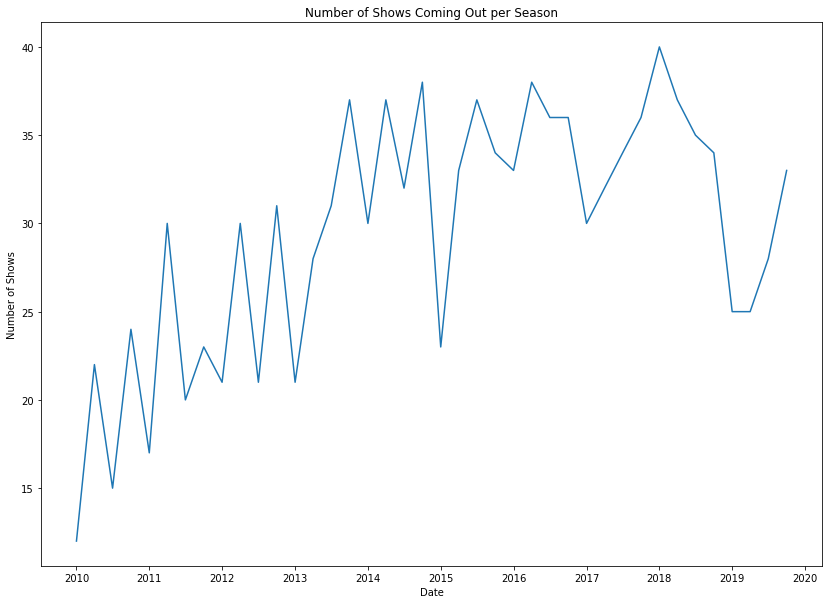

```python
fig, ax = plt.subplots(figsize=(14,10))
# shows in the same season have the exact same datetime
ax.plot(df.groupby('datetime').size())
ax.set_xlabel('Date')
ax.set_ylabel('Number of Shows')
ax.set_title('Number of Shows Coming Out per Season')
fig.show()
```

In the plot above, we can see how many shows have been released for each season-year pair. Generally, it appears that the amount of shows being released for each season is increasing with time. This is expected, because the overall popularity of anime has increased over the past decade.

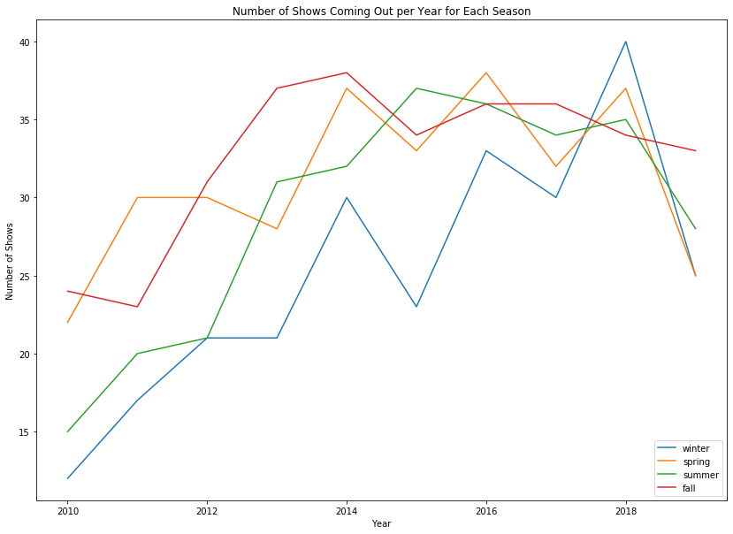

```python
fig, ax = plt.subplots(figsize=(14,10))
# for each sesaon, plot the number of shows for each year
for season in ['winter','spring','summer','fall']:
    ax.plot(df[df['season'] == season].groupby('year').size(), label=season)
ax.set_xlabel('Year')
ax.set_ylabel('Number of Shows')
ax.set_title('Number of Shows Coming Out per Year for Each Season')
ax.legend(loc='lower right')
fig.show()
```

The plot above breaks the previous plot into seasons, and for each season it plots the amount of shows coming out per year. Interestingly, it appears that the winter season consistently has the least amount of shows coming out per year until 2018. Also, all seasons are trending down in 2019 compared to 2018. This could be because the data in the data set is actually the amount of shows per season with greater than 30000 members, as recorded by MyAnimeList. A possible explanation for this dip is that maybe the shows in 2019 have have yet to break past the 30000 member mark on MyAnimeList and are thus not in our data set. This could be the case because people might have been putting off shows from 2019, whereas they've had more time to watch older shows, so there are more shows from older seasons that have passed the 30000 member mark.

Next, let's take a look at community scores.

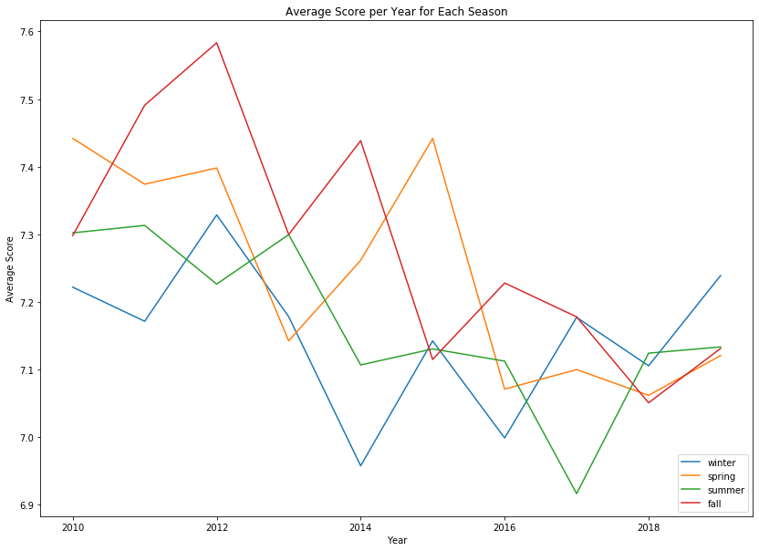

```python
fig, ax = plt.subplots(figsize=(14,10))
# for each sesaon, plot the average score for each year
for season in ['winter','spring','summer','fall']:
    ax.plot(df[df['season'] == season].groupby('year')['score'].mean(), label=season)
ax.set_xlabel('Year')
ax.set_ylabel('Average Score')
ax.set_title('Average Score per Year for Each Season')
ax.legend(loc='lower right')
fig.show()
```

The above plot shows the average score of the shows from each season plotted against year. It looks like each season is trending downward at about the same rate, but wait why is the average score trending down? Does this mean that anime has gotten worse over the years? I personally don't think that this is the case, and a possible explanation is that as anime has gotten more popular in the past decade, the people joining the community tend to watch more of the current shows, even if they're bad, and can pick and choose out of the shows that have already aired. So new anime watchers might tend to watch recent shows, even if they're bad, in order to keep up with discussions, but choose shows they know they'll like when watching shows that have already aired. Another possible explanation is related to the number of shows vs time plot we made earlier: even though more shows are being produced, the average quality is decreasing because creators are prioritizing quantity over quality. But why might creators prioritize quantity over quality? Taking things a step further, some people in the community have speculated that some anime creators have realized that most of the profit in the anime making business comes from things such as merchandise sales, or sales of the anime's source material (manga, novels, etc). Perhaps some studios only work on a show until it's reached some minimum level of quality to guarantee enough sales to maximize profit. I don't know if this theory is true, but the plots we've made showing the increase in quantity and decrease in quality (as defined by user scores) seem to support this theory.

```
The slope of the line is 0.15386701575312103 and the y intercept is 720.9523490982009
For this data set, the average score rank is 3291.1458863443595 and the average popularity rank is 1227.351145038168
```

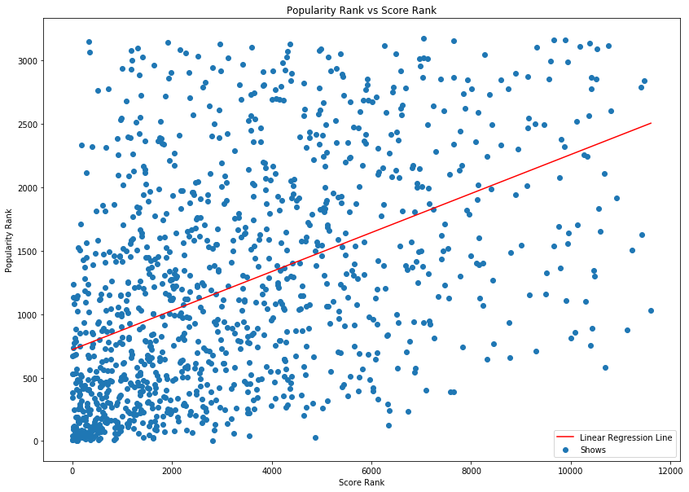

```python
fig, ax = plt.subplots(figsize=(14,10))
# for each show, plot its (score_rank, popularity_rank) point
ax.scatter(df['score_rank'],df['popularity_rank'],label='Shows')
ax.set_xlabel('Score Rank')
ax.set_ylabel('Popularity Rank')
ax.set_title('Popularity Rank vs Score Rank')

# get a linear regression for the points
reg_data = df[['score_rank','popularity_rank']]
reg = linear_model.LinearRegression()
reg.fit(reg_data.drop('popularity_rank',axis=1),reg_data['popularity_rank'])

# m is the slope and b is the y intercept
m = reg.coef_[0]
b = reg.intercept_

# plot a line for the fitted line by using the min and max x values of the scatter plot's points
min_x = df['score_rank'].min()
max_x = df['score_rank'].max()
x_pts = np.array([min_x,max_x])
ax.plot(x_pts,x_pts * m + b,c='r',label='Linear Regression Line')

ax.legend(loc='lower right')
fig.show()

print('The slope of the line is {} and the y intercept is {}'.format(m,b))
print('For this data set, the average score rank is {} and the average popularity rank is {}'.format(df['score_rank'].mean(),df['popularity_rank'].mean()))
```

The plot above plots each show's score ranking vs its popularity ranking. To understand what these variables mean, if a show's score ranking was #1 and it's popularity ranking was #30, it would be the #1 highest rated show and the 30th most watched show. So what does the plot tell us about score ranking and popularity ranking? From the best fit line, people do tend to watch shows that are ranked highly more. However, shows from this period are watched much more than than their score rankings would suggest. The slope of the best fit line is 0.1539, which means that for each change of 1 in a show's score rank, the popularity rank only changes by 0.1539. According to the best fit line for this data, the highest ranked shows at around #1 to #10 would only have an average rank of about #721 in terms of popularity. Even though the average score rank of the shows is around 3291, the average popularity rank is about 1227.

Let's now try to quantify popularity in the context of each season. For each season, which shows are the most popular? To start to answer this question, let's look at the distribution of members for each show.

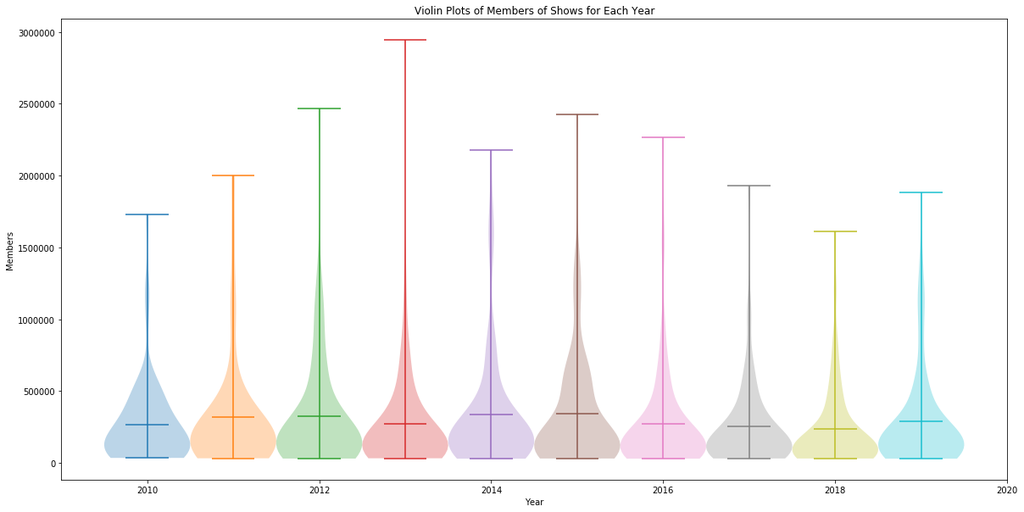

```python
years = range(2010,2020)
# get a list where the elements are series for each year
members_per_year = [(df[df['year'] == year])['members'] for year in years]

fig, ax = plt.subplots(figsize=(20,10))
# create violin plots of the members of shows for each year
for i,members in enumerate(members_per_year):
    ax.violinplot(members,[years[i]],widths=1,showmeans=True)
ax.set_xlabel('Year')
ax.set_ylabel('Members')
ax.set_title('Violin Plots of Members of Shows for Each Year')
fig.show()
```

These violin plots show the distribution of a show's members for each year. They are very skewed to the lower end, which suggests that there are a few extremely popular shows and a small amount of popular shows, but most shows are on the less popular end. This might be problematic if we wanted to analyze shows based on their relative popularity in their respective season, so let's define a transformation to get a more normally distributed variable. The transformation we're going to use is taking the log of the members variable.

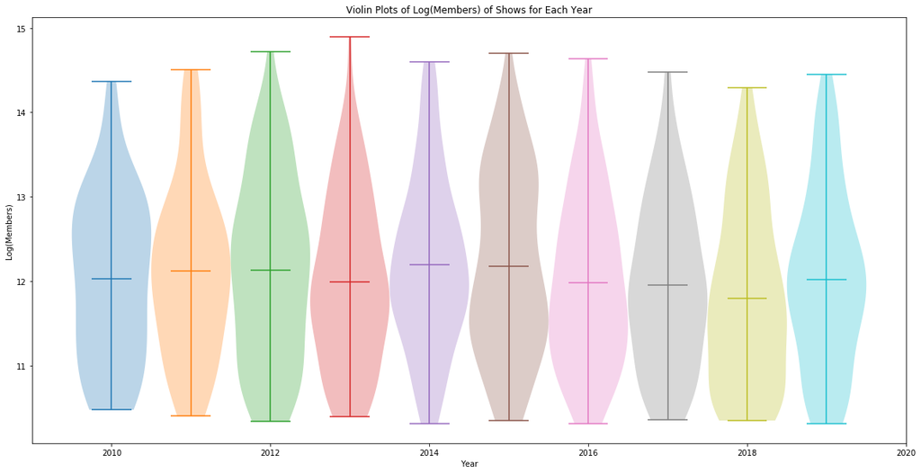

```python
# create a new column that is the log of the members column
df['log_members'] = df.apply(lambda x:np.log(x['members']), axis=1)

years = range(2010,2020)
# get a list where the elements are series for each year
members_per_year = [(df[df['year'] == year])['log_members'] for year in years]

fig, ax = plt.subplots(figsize=(20,10))
# create violin plots of the log(members) of shows for each year
for i,members in enumerate(members_per_year):
    ax.violinplot(members,[years[i]],widths=1,showmeans=True)
ax.set_xlabel('Year')
ax.set_ylabel('Log(Members)')
ax.set_title('Violin Plots of Log(Members) of Shows for Each Year')
fig.show()
```

Nice! The distribution on the log of the members variable is way less scewed than just the members. Next, we're going to define a variable that will give us some insight in a show's popularity relative to its season. The new variable is going to be using the mean and standard deviation of each season's log(memebers) variables. For each show, the new variable is going to be equal to the row's log(members) minus the season's average, and finally divide that difference by the season's standard deviation. Essentially what this new variable will tell us is how far apart, in units of standard deviations, the show's log(members) is from the mean. Also, even though the plots are for each year, we'll be doing this for each year-season pair. The reason why there isn't a violin plot for each season is because 40 plots would be too much, and they won't be different enough from doing the plots on a per year basis to justify making 40 plots instead of 10.

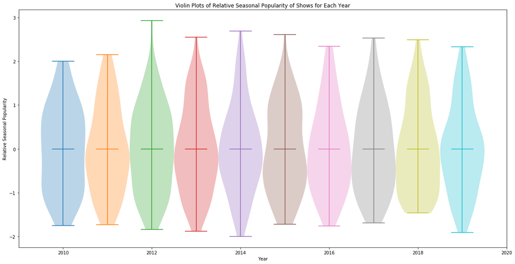

```python
# get the mean and std of each datetime group
means = df.groupby('datetime')['log_members'].mean()
stds = df.groupby('datetime')['log_members'].std()

# create a new column that measures the distance of a show's log_members from the mean, measured in units of std
df['relative_seasonal_popularity'] = df.apply(lambda x:(x['log_members'] - means[x['datetime']]) / stds[x['datetime']], axis=1)

years = range(2010,2020)
# get a list where the elements are series for each year
members_per_year = [(df[df['year'] == year])['relative_seasonal_popularity'] for year in years]

fig, ax = plt.subplots(figsize=(20,10))
# create violin plots of the relative seasonal popularity of shows for each year
for i,members in enumerate(members_per_year):
    ax.violinplot(members,[years[i]],widths=1,showmeans=True)
ax.set_xlabel('Year')
ax.set_ylabel('Relative Seasonal Popularity')
ax.set_title('Violin Plots of Relative Seasonal Popularity of Shows for Each Year')
fig.show()
```

Alright, now we've got a measure of a show's popularity relative to it's season! Let's check out how this variable relates to other measurements.

```
The slope of the line is 0.6455030966087199 and the y intercept is -4.648295721205199
```

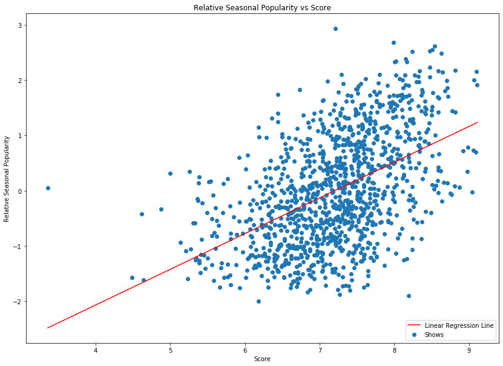

```python
fig, ax = plt.subplots(figsize=(14,10))
# for each show, plot its (score, relative_seasonal_popularity) point
ax.scatter(df['score'],df['relative_seasonal_popularity'],label='Shows')
ax.set_xlabel('Score')
ax.set_ylabel('Relative Seasonal Popularity')
ax.set_title('Relative Seasonal Popularity vs Score')

# get a linear regression for the points
reg_data = df[['score','relative_seasonal_popularity']]
reg = linear_model.LinearRegression()
reg.fit(reg_data.drop('relative_seasonal_popularity',axis=1),reg_data['relative_seasonal_popularity'])

# m is the slope and b is the y intercept
m = reg.coef_[0]
b = reg.intercept_

# plot a line for the fitted line by using the min and max x values of the scatter plot's points
min_x = df['score'].min()
max_x = df['score'].max()
x_pts = np.array([min_x,max_x])
ax.plot(x_pts,x_pts * m + b,c='r',label='Linear Regression Line')

ax.legend(loc='lower right')
fig.show()

print('The slope of the line is {} and the y intercept is {}'.format(m,b))

fig.show()
```

As shown above, it looks like there is generally a linear dependence of relative seasonal popularity to score, and that shows with a higher score tend to be more popular in their respective seasons. This makes sense because higher scored shows tend to be better, and people enjoy watching good shows more than watching bad ones.

Next, let's look at genre and how it relates to the other variables. First, we'll turn the unique genres in the 'genres' column into dummy variables. Dummy variables turn a categorical data type into being represented by a 1 or a 0. For example, because 'action' is one of the possible genres a show can have, each row in our dataframe will now have a column called 'action,' and if a show has 'action' as one of its genres, its 'action' column will have a 1. Else, the 'action' column will have a 0. Turning our genres into dummy variables is a way of quantifying whether a row has a property or not. This makes handling data related to a show's genres easier.

```python
def GetGenreDummy(row, genre):
    '''
    This function takes in a row and a genre and sees if the genre is in the row's 'genres' column.
    If it is, it returns 1. Else, it returns 0.
    '''
    if "'" + genre + "'" in row['genres']:
        return 1
    return 0

all_genres = ['Action', 'Mystery', 'Supernatural', 'Comedy', 'Romance', 'School', 'Super Power', 'Adventure', 'Historical', 'Martial Arts', 'Ecchi', 'Seinen', 'Harem', 'Demons', 'Fantasy', 'Drama', 'Vampire', 'Military', 'Sci-Fi', 'Music', 'Slice of Life', 'Josei', 'Horror', 'Shoujo', 'Magic', 'Psychological', 'Thriller', 'Samurai', 'Shounen Ai', 'Sports', 'Shounen', 'Kids', 'Game', 'Parody', 'Mecha', 'Shoujo Ai', 'Dementia', 'Space', 'Police', 'Cars']

# create dummy variables for all the genres
for genre in all_genres:
    df[genre] = df.apply(lambda x: GetGenreDummy(x, genre), axis=1)

# for every genre, print out how many shows have that genre
for genre in all_genres:
    shows_with_genre = df[df[genre] == 1]
    print('There are {} shows that are in the genre {}'.format(shows_with_genre.groupby(genre).size()[1],genre))
```

```
There are 456 shows that are in the genre Action
There are 118 shows that are in the genre Mystery
There are 255 shows that are in the genre Supernatural
There are 565 shows that are in the genre Comedy
There are 309 shows that are in the genre Romance
There are 363 shows that are in the genre School
There are 76 shows that are in the genre Super Power
There are 159 shows that are in the genre Adventure
There are 63 shows that are in the genre Historical
There are 20 shows that are in the genre Martial Arts
There are 152 shows that are in the genre Ecchi
There are 160 shows that are in the genre Seinen
There are 114 shows that are in the genre Harem
There are 65 shows that are in the genre Demons
There are 300 shows that are in the genre Fantasy
There are 256 shows that are in the genre Drama
There are 27 shows that are in the genre Vampire
There are 50 shows that are in the genre Military
There are 180 shows that are in the genre Sci-Fi
There are 53 shows that are in the genre Music
There are 255 shows that are in the genre Slice of Life
There are 24 shows that are in the genre Josei
There are 41 shows that are in the genre Horror
There are 56 shows that are in the genre Shoujo
There are 110 shows that are in the genre Magic
There are 64 shows that are in the genre Psychological
There are 21 shows that are in the genre Thriller
There are 23 shows that are in the genre Samurai
There are 13 shows that are in the genre Shounen Ai
There are 69 shows that are in the genre Sports
There are 234 shows that are in the genre Shounen
There are 11 shows that are in the genre Kids
There are 53 shows that are in the genre Game
There are 38 shows that are in the genre Parody
There are 53 shows that are in the genre Mecha
There are 20 shows that are in the genre Shoujo Ai
There are 7 shows that are in the genre Dementia
There are 21 shows that are in the genre Space
There are 13 shows that are in the genre Police
There are 2 shows that are in the genre Cars
```

Now that we have a column corresponding to each possible genre, let's take a look at Action shows and see if we can find some interesting relations.

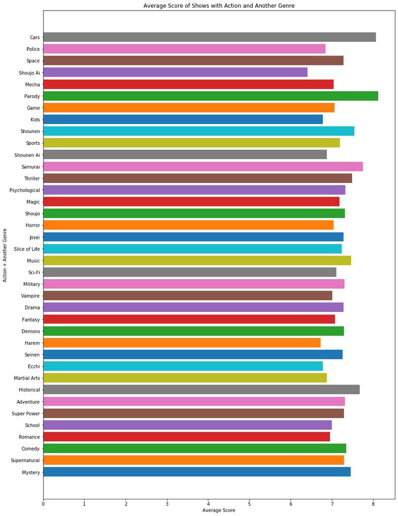

```python
# get all the shows that have the "Action" genre
action_shows = df[df['Action'] == 1]

fig, ax = plt.subplots(figsize=(14,20))
# for each genre except for action, plot a bar for its average score
for genre in all_genres:
    if genre == 'Action':
        continue
    # skip if the secondary genre has no overlap with action shows
    elif action_shows[action_shows[genre] == 1].size == 0:
            continue
    else:
        ave_score = action_shows[action_shows[genre] == 1]['score'].mean()
        ax.barh(genre,ave_score)

ax.set_xlabel('Average Score')
ax.set_ylabel('Action + Another Genre')
ax.set_title('Average Score of Shows with Action and Another Genre')

fig.show()
```

The above plot shows the average score of shows that have the genres Action plus another genre. Oddly, it seems that shows that have the genres Action and Parody are the most highly ranked over all pairs of Action + another genre. Unsurprisingly, Action shows tend to be scored higher if they have other genres such as Cars, Samurai, Historical, or Thriller. The genre that Action does the worst with is Shoujo Ai, which is a sub genre of romance dealing with specifically girl to girl relationships.

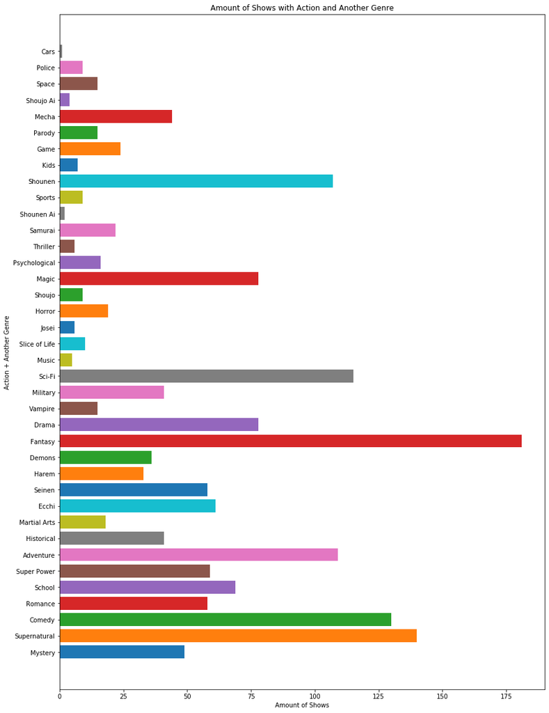

```python
fig, ax = plt.subplots(figsize=(14,20))
# for each genre except for action, plot a bar for the amount of shows
for genre in all_genres:
    if genre == 'Action':
        continue
    # skip if the secondary genre has no overlap with action shows
    elif action_shows[action_shows[genre] == 1].size == 0:
            continue
    else:
        count = action_shows[action_shows[genre] == 1].shape[0]
        ax.barh(genre,count)

ax.set_xlabel('Amount of Shows')
ax.set_ylabel('Action + Another Genre')
ax.set_title('Amount of Shows with Action and Another Genre')

fig.show()
```

This plot shows the total amount of shows for each Action + other genre pair. It seems that Fantasy is by far the genre that is most often paired with Action. The Cars genre had a very higher average score in the previous plot, but here we can see that it's not at all very popular. This could mean that the previous plot scored Cars very highly because there simply weren't many Action + Cars shows, and those that existed were done very well.

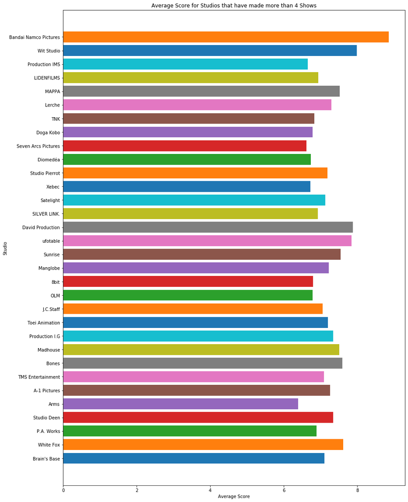

```python
fig, ax = plt.subplots(figsize=(14,20))
# for each studio, plot the average score if they've made more than 4 action shows
for studio in action_shows['studio'].unique():
    action_studio = action_shows[action_shows['studio'] == studio]
    if action_studio.shape[0] < 5:
        continue
    else:
        ax.barh(studio,action_studio['score'].mean())

ax.set_xlabel('Average Score')
ax.set_ylabel('Studio')
ax.set_title('Average Score for Studios that have made more than 4 Shows')

fig.show()
```

This plot shows the average score of action shows for studios that have made more than 4 action shows over the years 2010 to 2019. It looks like the studios that make the best action shows are Bandai Namco Pictures, Wit Studio, David Production, and Ufotable. As an anime fan, I recognized the last 3 but not the first one. A quick lookup reveals that this is because the later 3 studios have made a decent amount of action shows of different franchises, but most of Bandai Namco Pictures' action shows are of a single franchise, Gintama, which as a series is very highly rated.

And with that, the exploratory data analysis phase of the pipeline is over. Because our data had so many features, we only scratched the surface on the plots we could have done. If you're interested in other plots we possibly could have made, Matplotlib has an excellent gallery of example plots that are possible to be made here: https://matplotlib.org/stable/gallery/index.html

## Hypothesis Testing

Now that we have a decent feel for the data, it's time to get concrete. Let's formally specify a hypothesis and test it. To test a hypothesis, we'll have to come up with the null hypothesis that's specific to that hypothesis, and reject it. The null hypothesis is basically what we would expect if our hypothesis wasn't true. We reject the null hypothesis by doing a p-test and rejecting it if the p-value is less than 0.05.  
Let's start with something simple. Let our hypothesis be that we can predict a show's relative seasonal popularity linearly from the show's score. The null hypothesis would then be that there is no linear predictive power of relative seasonal popularity in score. So if we were to plot a linear regression for relative seasonal popularity vs score, the null hypothesis would expect a trend line that is statistically horizontal (it has a p-value of > 0.05). So let's get a best fit line and see what the p-value for the slope is to see if we can reject the null hypothesis.

```
The slope of the line is 0.6455030966087199 and the y intercept is -4.648295721205199
                                 OLS Regression Results
========================================================================================
Dep. Variable:     relative_seasonal_popularity   R-squared:                       0.249
Model:                                      OLS   Adj. R-squared:                  0.248
Method:                           Least Squares   F-statistic:                     390.0
Date:                          Wed, 21 Jul 2021   Prob (F-statistic):           3.30e-75
Time:                                  12:49:24   Log-Likelihood:                -1483.9
No. Observations:                          1179   AIC:                             2972.
Df Residuals:                              1177   BIC:                             2982.
Df Model:                                     1
Covariance Type:                      nonrobust
==============================================================================
                 coef    std err          t      P>|t|      [0.025      0.975]
------------------------------------------------------------------------------
const         -4.6483      0.237    -19.640      0.000      -5.113      -4.184
score          0.6455      0.033     19.749      0.000       0.581       0.710
==============================================================================
Omnibus:                       26.279   Durbin-Watson:                   0.883
Prob(Omnibus):                  0.000   Jarque-Bera (JB):               16.136
Skew:                           0.131   Prob(JB):                     0.000313
Kurtosis:                       2.490   Cond. No.                         70.3
==============================================================================

Warnings:
[1] Standard Errors assume that the covariance matrix of the errors is correctly specified.
```

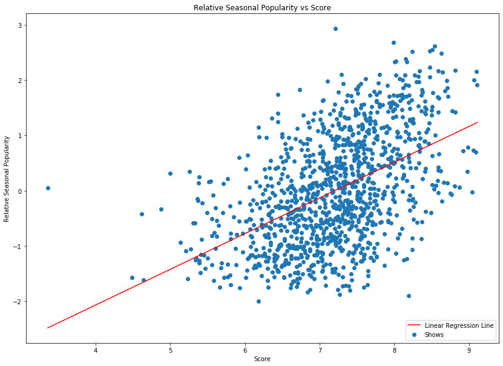

```python
fig, ax = plt.subplots(figsize=(14,10))
# for each show, plot its (score, relative_seasonal_popularity) point
ax.scatter(df['score'],df['relative_seasonal_popularity'],label='Shows')
ax.set_xlabel('Score')
ax.set_ylabel('Relative Seasonal Popularity')
ax.set_title('Relative Seasonal Popularity vs Score')

# get a linear regression for the points
reg_data = df[['score','relative_seasonal_popularity']]
reg = linear_model.LinearRegression()
reg.fit(reg_data.drop('relative_seasonal_popularity',axis=1),reg_data['relative_seasonal_popularity'])

# m is the slope and b is the y intercept
m = reg.coef_[0]
b = reg.intercept_

# plot a line for the fitted line by using the min and max x values of the scatter plot's points
min_x = df['score'].min()
max_x = df['score'].max()
x_pts = np.array([min_x,max_x])
ax.plot(x_pts,x_pts * m + b,c='r',label='Linear Regression Line')

ax.legend(loc='lower right')
fig.show()

print('The slope of the line is {} and the y intercept is {}'.format(m,b))

fig.show()


# use statsmodels
# organize the data into X,Y
X1 = reg_data.drop('relative_seasonal_popularity',axis=1)
Y = reg_data['relative_seasonal_popularity']
# add a contant
X2 = sm.add_constant(X1)

# do a linear regression and get some statistics for it
reg1 = sm.OLS(Y, X2)
reg2 = reg1.fit()
print(reg2.summary())
```

Reading from the table that was outputted, the p-value for the slope is appoximately zero when rounding to 3 decimal places, which means that the p-value is less than 0.05. Because of this, we can reject the null hypothesis. We also have an explanation for why relative season popularity would have a linear dependence on score: people tend to watch shows that are scored higher. Because we can reject the null hypothesis, we can conclude that our hypothesis is a plausible explanation.  
But wait a second, we've actually already made this exact plot! Before when we made this plot, we could only make an eyeball estimate on the relationship between relative seasonal popularity and score, but now we have shown statistically that the linear relationship is significant. That was a fairly simple example of hypothesis testing, so let's come up with another hypothesis. We saw earlier that the average score was trending downwards against time. Can we do a multilinear regression that predicts the relative seasonal popularity using score, while also accounting for how score behaves vs time? We could add another linear variable based on the year, but year might not be the best choice because relative seasonal popularity should not be dependent on time because of how we constructed the variable "relative season popularity". We basically made "relative season popularity" a variable that was independent of time so that we could compare popularity in the context of each season. A better idea might be to create a new cross term variable year*score. So then our hypothesis is that there is a linear relationship between relative seasonal popularity and both score and year*score. Our null hypothesis is the same as last time, that there is no such linear relationship. Let's get the multilinear regression and see what the p-values are.

```python
# create a new column for score*year
df['score*year'] = df.apply(lambda x: x['score'] * x['year'], axis=1)

# get a linear regression for the points
reg_data = df[['score','score*year','relative_seasonal_popularity']]
reg = linear_model.LinearRegression()
reg.fit(reg_data.drop('relative_seasonal_popularity',axis=1),reg_data['relative_seasonal_popularity'])

m1 = reg.coef_[0]
m2 = reg.coef_[1]
b = reg.intercept_

print('The coefficient for score is {}'.format(m1))
print('The coefficient for score*year is {}'.format(m2))
print('The intercept is {}'.format(b))


# use statsmodels
# organize the data into X,Y
X1 = reg_data.drop('relative_seasonal_popularity',axis=1)
Y = reg_data['relative_seasonal_popularity']
# add a contant
X2 = sm.add_constant(X1)

# do a linear regression and get some statistics for it
reg1 = sm.OLS(Y, X2)
reg2 = reg1.fit()
print(reg2.summary())
```

```
The coefficient for score is -5.184611074660463
The coefficient for score*year is 0.0028970818081757925
The intercept is -4.699582703348327
                                 OLS Regression Results
========================================================================================
Dep. Variable:     relative_seasonal_popularity   R-squared:                       0.252
Model:                                      OLS   Adj. R-squared:                  0.251
Method:                           Least Squares   F-statistic:                     198.3
Date:                          Wed, 21 Jul 2021   Prob (F-statistic):           6.15e-75
Time:                                  12:53:24   Log-Likelihood:                -1481.3
No. Observations:                          1179   AIC:                             2969.
Df Residuals:                              1176   BIC:                             2984.
Df Model:                                     2
Covariance Type:                      nonrobust
==============================================================================
                 coef    std err          t      P>|t|      [0.025      0.975]
------------------------------------------------------------------------------
const         -4.6996      0.237    -19.802      0.000      -5.165      -4.234
score         -5.1846      2.559     -2.026      0.043     -10.206      -0.163
score*year     0.0029      0.001      2.278      0.023       0.000       0.005
==============================================================================
Omnibus:                       23.724   Durbin-Watson:                   0.897
Prob(Omnibus):                  0.000   Jarque-Bera (JB):               15.233
Skew:                           0.135   Prob(JB):                     0.000492
Kurtosis:                       2.513   Cond. No.                     1.51e+06
==============================================================================

Warnings:
[1] Standard Errors assume that the covariance matrix of the errors is correctly specified.
[2] The condition number is large, 1.51e+06. This might indicate that there are
strong multicollinearity or other numerical problems.
```

So as before, we can reject the null hypothesis because the p-values are less than 0.05. However, it's worth noting that the p-values just barely make the cuttoff, so maybe the significance of the linear relationship for these variables is less than we would have hoped for. However, because the p-values are less than 0.05, we can reject the null hypothesis, so our hypothesis is plausible.

## Machine Learning

#### The Model

We've already seen that certain variables have predictive power in predicting the relative seasonal popularity, but can we do better than linear regression with machine learning? The answer is yes. The method we will be using is a k-nearest neighbors classifier (k-NN). k-NN uses shows that are "close" (in some mathematical sense) to a show, and determines what that show's class would be using the k nearest neighbors to that class. I believe that this machine learning method makes sense because shows with similar features will be "close" to each other and are expected to behave roughly the same. I mentioned that we will be using a classifier, so what are the classes that our machine learning model is trying to predict? Let's keep things simple and make 2 classes: class "A" corresponds to shows with a relative seasonal popularity of greater than 0, and class "B" corresponds to shows with a relative season popularity of less than or equal to 0. Another thing we need to consider is how many nearest neighbors each show should have. Let's try testing the model with many different nearest neighbors, and see which ones do better. More information of k-NN is available here: https://en.wikipedia.org/wiki/K-nearest_neighbors_algorithm

#### Testing the Model

We've chosen a machine learning model, but how do we test it? A common danger in machine learning is overfitting, which means that even though the model can predict the training set's classes extremely well, it fails at predicting new datas' classes because the model is biased towards the input data. One way to get around this is to randomly cut the data into 2 parts: a training set and a testing set. An even better approach is n-fold cross validation, which breaks the data down into n groups. Even though it's more computationally expensive, n-fold cross validation can give us a realiable estimate on the accuracy of our model without the worry that we're overfitting our model. More information on n-fold cross validation is available here: https://scikit-learn.org/stable/modules/cross_validation.html

```python
def GetClass(row):
    '''
    This function is used to give each show a class based on its relative season popularity
    '''
    if row['relative_seasonal_popularity'] > 0:
        return 'A'
    else:
        return 'B'

# create a new column for class
df['class'] = df.apply(GetClass, axis=1)

# choosing which columns to train our model on
ind_cols = ['score','score*year']

# the data sets for the input data and the target data
ind = df[ind_cols]
dep = df['class']

for k in range(1,50,4):
    KNN_classifier = KNeighborsClassifier(k)
    score = cross_val_score(KNN_classifier, ind, dep, cv=10).mean()

    print('The accuracy of the classifier with {} nearest neighbors as given by a 10-fold cross validation is: {}'.format(k,score))
```

```
The accuracy of the classifier with 1 nearest neighbors as given by a 10-fold cross validation is: 0.6048650751043573
The accuracy of the classifier with 5 nearest neighbors as given by a 10-fold cross validation is: 0.6201347727269961
The accuracy of the classifier with 9 nearest neighbors as given by a 10-fold cross validation is: 0.6387656931525326
The accuracy of the classifier with 13 nearest neighbors as given by a 10-fold cross validation is: 0.6395412054434986
The accuracy of the classifier with 17 nearest neighbors as given by a 10-fold cross validation is: 0.6327971518898738
The accuracy of the classifier with 21 nearest neighbors as given by a 10-fold cross validation is: 0.6430104679855428
The accuracy of the classifier with 25 nearest neighbors as given by a 10-fold cross validation is: 0.6396417584852282
The accuracy of the classifier with 29 nearest neighbors as given by a 10-fold cross validation is: 0.6473123364947893
The accuracy of the classifier with 33 nearest neighbors as given by a 10-fold cross validation is: 0.65490396941045
The accuracy of the classifier with 37 nearest neighbors as given by a 10-fold cross validation is: 0.6625245752364398
The accuracy of the classifier with 41 nearest neighbors as given by a 10-fold cross validation is: 0.6481097002034192
The accuracy of the classifier with 45 nearest neighbors as given by a 10-fold cross validation is: 0.6489570360956203
The accuracy of the classifier with 49 nearest neighbors as given by a 10-fold cross validation is: 0.6523615965290941
```

The best accuracy we got was around 66%, which is hardly better than a coin flip (it's pretty bad). Instead of trying to predict if a show is in the popular half or the not popular half, let's try classifying shows based on ones that are very popular and shows that aren't. This way, our model might have a higher accuracy, and the model might be more useful or interesting if our goal is to identify the most popular shows for each season.

```python
def GetClass(row):
    '''
    This function is used to give each show a class based on its relative season popularity
    '''
    if row['relative_seasonal_popularity'] > 1: #now we're only tring to predict if a show is very popular or not
        return 'popular'
    else:
        return 'not popular'

# create a new column for class
df['class'] = df.apply(GetClass, axis=1)

# choosing which columns to train our model on
ind_cols = ['score','score*year']

# the data sets for the input data and the target data
ind = df[ind_cols]
dep = df['class']

for k in range(1,50,4):
    KNN_classifier = KNeighborsClassifier(k)
    score = cross_val_score(KNN_classifier, ind, dep, cv=10).mean()

    print('The accuracy of the classifier with {} nearest neighbors as given by a 10-fold cross validation is: {}'.format(k,score))
```

```
The accuracy of the classifier with 1 nearest neighbors as given by a 10-fold cross validation is: 0.75838351855301
The accuracy of the classifier with 5 nearest neighbors as given by a 10-fold cross validation is: 0.8109197438210399
The accuracy of the classifier with 9 nearest neighbors as given by a 10-fold cross validation is: 0.8202490209469273
The accuracy of the classifier with 13 nearest neighbors as given by a 10-fold cross validation is: 0.8219153284955878
The accuracy of the classifier with 17 nearest neighbors as given by a 10-fold cross validation is: 0.8201916838008565
The accuracy of the classifier with 21 nearest neighbors as given by a 10-fold cross validation is: 0.8168089747850467
The accuracy of the classifier with 25 nearest neighbors as given by a 10-fold cross validation is: 0.8151356674786385
The accuracy of the classifier with 29 nearest neighbors as given by a 10-fold cross validation is: 0.8185111332668662
The accuracy of the classifier with 33 nearest neighbors as given by a 10-fold cross validation is: 0.8185112550017836
The accuracy of the classifier with 37 nearest neighbors as given by a 10-fold cross validation is: 0.8244218504437846
The accuracy of the classifier with 41 nearest neighbors as given by a 10-fold cross validation is: 0.8176565541470827
The accuracy of the classifier with 45 nearest neighbors as given by a 10-fold cross validation is: 0.8235743928166661
The accuracy of the classifier with 49 nearest neighbors as given by a 10-fold cross validation is: 0.8210681143383038
```

Ok, so this model is much better in terms of accuracy. It would appear that it's easier for out model to predict if a show is very popular or not as opposed to predicting if a show is in the more popular half of a season or not.

## Conclusions

As a recap of the tutorial, we have gone over the following steps of the data science pipeline:

1. Data Collection - Using the very tedious and time consuming method of web scraping, we acquired out data
2. Data Tidying - We made our data easier to analyze by converting certain columns to numerical values and adding new columns.
3. Exploratory Data Analysis - We used Matplotlib to visualize the data we collected. Although we only scratched the surface of what we could have plotted, I think we visualized a decent chunk of the data we had. We also had to add some more columns in order to make measurements of certain aspects of our data easier.
4. Hypothesis Testing - We went over how to test a hypothesis using examples from our data set.
5. Machine Learning - We used a simple k-NN machine learning model to predict the relative seasonal popularity of our shows.

We've also obtained a number of interesting insights into our particular data set, such as:

1. The amount of shows with 30000 members or more coming out per season is generally increasing with time
2. The average score of shows with 30000 members or more coming out in this time period was trending downwards with time
3. This set of shows was generally higher ranked in terms of popularity rankings compared to score rankings
4. For each season, the relative popularity of a show was generally increasing with the show's score
5. Action shows were on average scored more highly when paired with certain genres, and scored lower when paired with others
6. The most common genre Action shows are grouped with is Fantasy
7. Certain studios are better at making action shows than others

And with that, the tutorial is concluded. Have a nice day!